# ICA 5

Jonathan Thompson

2024-03-18

## Customer Churn

In this assignment, you will estimate a survival analysis model on customer churn. In this dataset, you will find various characteristics about a set of phone company customers

customerID: Customer ID number gender: Provides the stated gender of the customer SeniorCitizen: States if the person is a senior citizen Partner: Does the person have a partner Dependents: Does the person have dependents tenure: States how long the person has been with the Bank PhoneService: Do they have phone service MultipleLines: Do they have multiple lines InternetService: What type of Internet Service do they have (DSL, fiber optic, none) OnlineSecurity: Do they have online security? OnlineBackup: Do they have online backup? DeviceProtection: Do they have device protection? TechSupport: Did they use tech support? StreamingTV: Do they use the internet to stream TV? StreamingMovies: Do they use the internet to stream movies? Contract: What type of contract do they have (month-to-month, one-year, or two year) PaperlessBilling: Do they use paperless biling PaymentMethod: How do they pay for services MonthlyCharges: What is their monthly charge? TotalCharges: What is their total charge for the quarter? Churn: Did they leave the company

1. Find the simple average of `tenure`. Explain why this simple average can be biased.

```r
library(readr)

Churn <- read.csv ("C:/Users/catho/OneDrive/Documents/AAT/WA_Fn-UseC_-Telco-Customer-Churn.csv")
```

2. Find the simple average of `tenure` by the following groups. Gender, SeniorCitizen, and Partner.

```r
Churn$SeniorCitizen <- factor(Churn$SeniorCitizen, labels= c("Non-Senior", "Senior"))

tab1 <- aggregate(Churn$tenure, by=list(Churn$gender, Churn$SeniorCitizen, Churn$Partner), FUN=mean)

names(tab1) <-c ("Gender", "Senior Status", "Partnered", "Mean of Tenure")

knitr::kable(tab1)
```

| Gender | Senior Status | Partnered | Mean of Tenure |
| --- | --- | --- | --- |
| Female | Non-Senior | No | 22.87432 |
| Male | Non-Senior | No | 23.18970 |
| Female | Senior | No | 24.85938 |
| Male | Senior | No | 25.37751 |
| Female | Non-Senior | Yes | 41.72639 |
| Male | Non-Senior | Yes | 42.55436 |
| Female | Senior | Yes | 42.63710 |
| Male | Senior | Yes | 40.54154 |

```r
library(modelsummary)

datasummary(tenure ~ Mean*(Gender=gender)+Mean*(`Senior Citizen`= SeniorCitizen)+Mean*(Partner), data=Churn)
```

|  | Gender Female | Gender Male | Senior Citizen Non-Senior | Senior Citizen Senior | Partner No | Partner Yes |
| --- | --- | --- | --- | --- | --- | --- |
| tenure | 32.24 | 32.50 | 32.19 | 33.30 | 23.36 | 42.02 |

3. Find the simple average of `tenure` and `MonthlyCharge` by `Contract` type.

```r
datasummary((`Tenure`=tenure)+(`Monthly Charge`= MonthlyCharges)~Mean*Contract, data=Churn)
```

|  | Month-to-month | One year | Two year |
| --- | --- | --- | --- |
| Tenure | 18.04 | 42.04 | 56.74 |
| Monthly Charge | 66.40 | 65.05 | 60.77 |

4. Estimate a Kaplan Meier survival model. Use gender and senior citizen as explanatory variables. Do these variables produce statistically different survival rates?

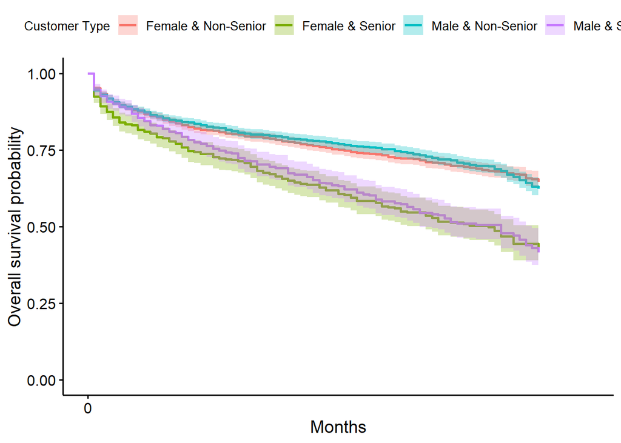

```r
Churn$delta <-ifelse(Churn$Churn=="Yes", 1, 0)

survminer::ggsurvplot(
    fit = survival::survfit(survival::Surv(tenure, delta) ~ gender+SeniorCitizen, data = Churn),
    xlab = "Months",
    ylab = "Overall survival probability",
    legend.title = "Customer Type",
    legend.labs = c("Female & Non-Senior", "Female & Senior", "Male & Non-Senior","Male & Senior"),
    break.x.by = 100,
    censor = FALSE,
    conf.int = TRUE)
```

5. Estimate a Kaplan Meier survival model that uses contract type as the explanatory variable. Do we see a difference between contract type?

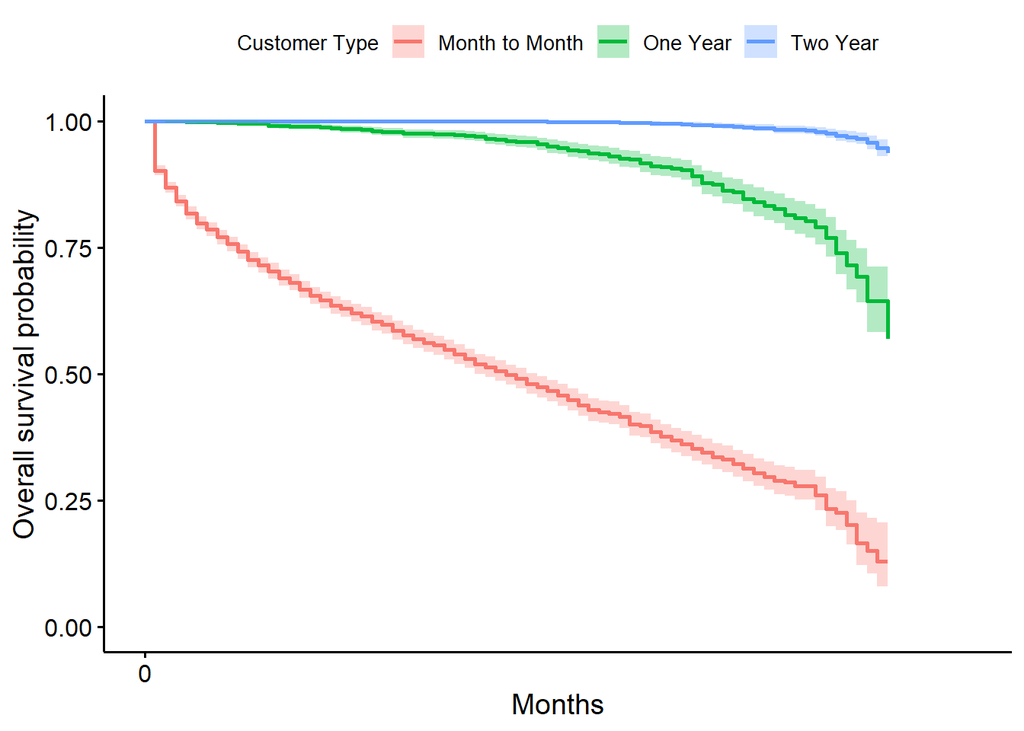

```r
Churn$delta <-ifelse(Churn$Churn=="Yes", 1, 0)

survminer::ggsurvplot(
    fit = survival::survfit(survival::Surv(tenure, delta) ~ Contract, data = Churn),
    xlab = "Months",
    ylab = "Overall survival probability",
    legend.title = "Customer Type",
    legend.labs = c("Month to Month", "One Year", "Two Year"),
    break.x.by = 100,
    censor = FALSE,
    conf.int = TRUE)
```

Answer: Yes, especially with the Month-To-Month contract type. Within this contract type, it instantly drops within the first month, gradually gets lower & ends at around a probability of .15. The One-Year contract type drops mildly lower as each month accrues but drops towards the very end month(s) at around .60. The Two-Year contract type has no difference in decline until they very end month(s) in the upper .90’s.

6. Estimate a Cox proportional hazard model of `tenure`. Use the following variables as explanatory variables: gender, Senior Citizen, contract type, partner, dependents, type of internet access, do they have phone service, and do they use paperless billing.

```r
library(broom)
library(survival)

model_cox <- survival::coxph(
  survival::Surv(tenure, delta) ~ gender + SeniorCitizen + Contract + Partner + Dependents + InternetService + PhoneService + PaperlessBilling,
  data = Churn)

tidy_broom <- broom::tidy(model_cox)

coef_names <- c("Male", "Senior Citizen", "One-Year Contract", "Two-Year Contract", "Yes To Partner", "Yes To Dependents", "Optic Internet Service", "No To Internet Service", "Yes To Phone Service", "Yes To Paperless Billing")

tidy_broom$term <- coef_names

colnames(tidy_broom)[2:5] <- c("Estimate", "Standard Error", "Statistic", "P-Value")

print(tidy_broom)
```

```
## # A tibble: 10 × 5
##    term                     Estimate `Standard Error` Statistic `P-Value`
##    <chr>                       <dbl>            <dbl>     <dbl>     <dbl>
##  1 Male                      -0.0443           0.0463    -0.956 3.39e-  1
##  2 Senior Citizen            -0.0626           0.0558    -1.12  2.62e-  1
##  3 One-Year Contract         -2.03             0.0850   -23.9   8.42e-126
##  4 Two-Year Contract         -3.90             0.160    -24.4   1.36e-131
##  5 Yes To Partner            -0.611            0.0543   -11.3   2.25e- 29
##  6 Yes To Dependents         -0.0946           0.0681    -1.39  1.65e-  1
##  7 Optic Internet Service     0.360            0.0678     5.32  1.05e-  7
##  8 No To Internet Service    -0.225            0.112     -2.00  4.53e-  2
##  9 Yes To Phone Service      -0.123            0.0974    -1.26  2.08e-  1
## 10 Yes To Paperless Billing   0.123            0.0561     2.20  2.80e-  2
```